# TF2_資料探索

卓雍然, 中山大學 管理學術研究中心

2019-12-07 10:53:02

```r
rm(list=ls(all=TRUE))
pacman::p_load(Matrix, vcd, magrittr, readr, caTools, ggplot2, dplyr)
load("data/tf0.rdata")
sapply(list(cust=A0,tid=X0,items=Z0), nrow)
```

```
##   cust    tid  items
##  32241 119328 817182
```

### 年齡與地理區隔

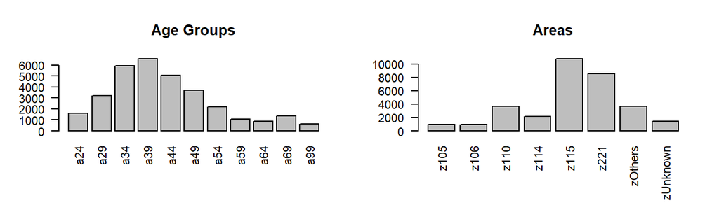

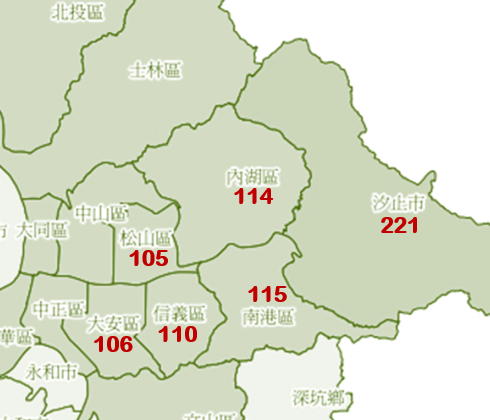

Fig-2: Zip Codes

```r
par(mfrow=c(1,2),cex=0.7)
table(A0$age) %>% barplot(las=2,main="Age Groups")
table(A0$area) %>% barplot(las=2,main="Areas")
```

##### 年齡與地理區隔的關聯性

使用馬賽克圖檢視列連表的關聯性(Association between Categorial Variables)

- 方塊大小代表該類別組合的數量
- 紅(藍)色代表該類別組合的數量顯著小(大)於期望值
- 期望值就是邊際機率(如上方的直條圖所示)的乘積
- 卡方檢定(類別變數的關聯性檢定)的p值顯示在圖示最下方
- `p-value < 2.22e-16` : `age` 與 `area` 之間有顯著的關聯性

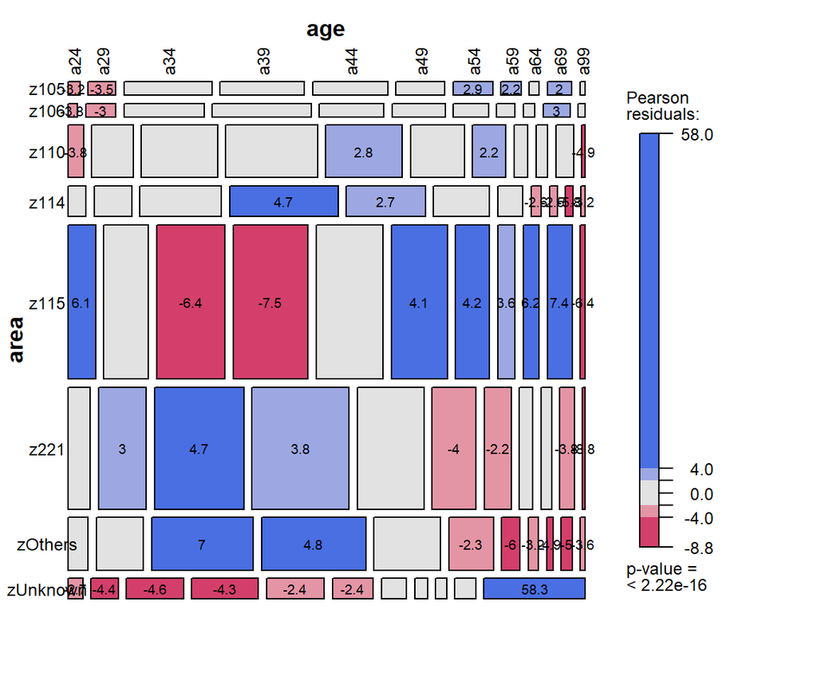

```r
MOSA = function(formula, data) mosaic(formula, data, shade=T,
  margins=c(0,1,0,0), labeling_args = list(rot_labels=c(90,0,0,0)),
  gp_labels=gpar(fontsize=9), legend_args=list(fontsize=9),
  gp_text=gpar(fontsize=7),labeling=labeling_residuals)

MOSA(~area+age, A0)
```

### 簡單泡泡圖

##### 年齡區隔特徵

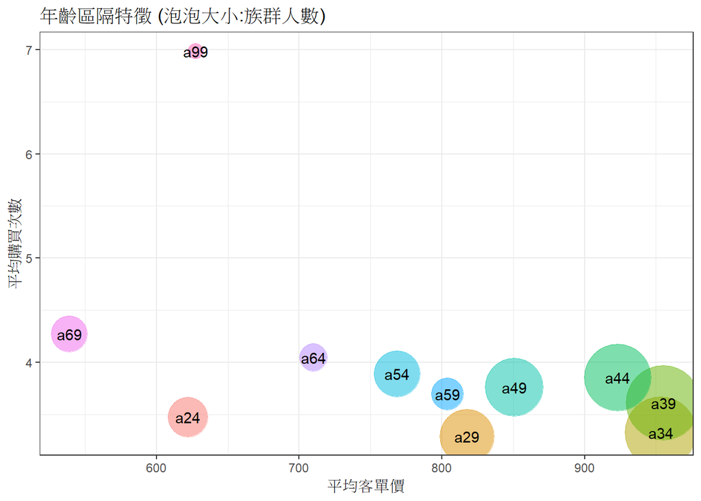

```r
A0 %>% group_by(age) %>% summarise(
  Group.Size = n(),              # 族群人數
  avg.Freq = mean(f),            # 平均購買次數
  avg.Revenue = sum(f*m)/sum(f)  # 平均客單價
  ) %>%
  ggplot(aes(y=avg.Freq, x=avg.Revenue)) +
  geom_point(aes(col=age, size=Group.Size), alpha=0.5) +
  geom_text(aes(label=age)) +
  scale_size(range=c(5,25)) +
  theme_bw() + theme(legend.position="none") +
  ggtitle("年齡區隔特徵 (泡泡大小:族群人數)") +
  ylab("平均購買次數") + xlab("平均客單價")
```

```r
mean(A0$age == "a99")
```

```
## [1] 0.01941627
```

由於`a99`(沒有年齡資料的顧客)人數不多，而且特徵很獨特，探索時我們可以考慮濾掉這群顧客

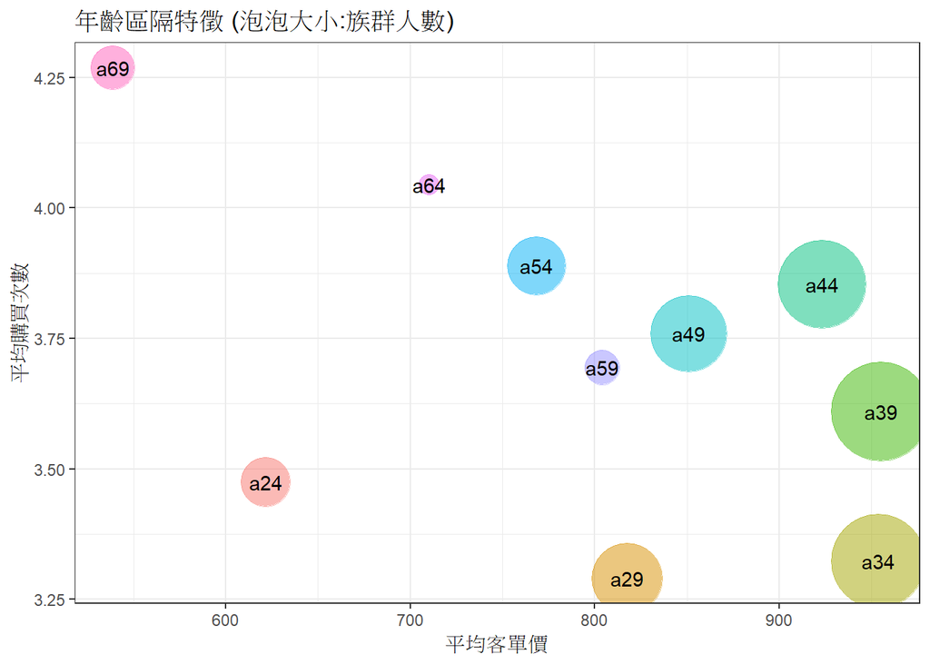

```r
A0 %>% filter(age!="a99") %>%    # 濾掉沒有年齡資料的顧客('a99')
  group_by(age) %>% summarise(
  Group.Size = n(),              # 族群人數
  avg.Freq = mean(f),            # 平均購買次數
  avg.Revenue = sum(f*m)/sum(f)  # 平均客單價
  ) %>%
  ggplot(aes(y=avg.Freq, x=avg.Revenue)) +
  geom_point(aes(col=age, size=Group.Size), alpha=0.5) +
  geom_text(aes(label=age)) +
  scale_size(range=c(5,25)) +
  theme_bw() + theme(legend.position="none") +
  ggtitle("年齡區隔特徵 (泡泡大小:族群人數)") +
  ylab("平均購買次數") + xlab("平均客單價")
```

##### 地理區隔特徵

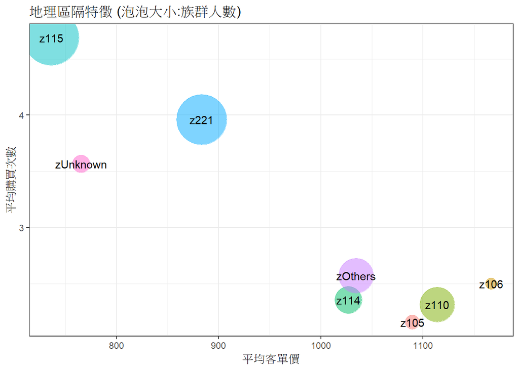

```r
A0 %>% filter(age!="a99") %>%    # 濾掉沒有年齡資料的顧客('a99')
  group_by(area) %>% summarise(
  Group.Size = n(),              # 族群人數
  avg.Freq = mean(f),            # 平均購買次數
  avg.Revenue = sum(f*m)/sum(f)  # 平均客單價
  ) %>%
  ggplot(aes(y=avg.Freq, x=avg.Revenue)) +
  geom_point(aes(col=area, size=Group.Size), alpha=0.5) +
  geom_text(aes(label=area)) +
  scale_size(range=c(5,25)) +
  theme_bw() + theme(legend.position="none") +
  ggtitle("地理區隔特徵 (泡泡大小:族群人數)") +
  ylab("平均購買次數") + xlab("平均客單價")
```

💡 主要發現：  
※ 「年齡」與「地區」之間有很高的關聯性  
§ 南港(`z115`)30~40歲的顧客比率比較低  
§ 汐止(`z221`)、內湖(`z114`)和其他(`zOthers`)30~40歲的顧客比率比較高  
※ 「平均購買次數」和「平均客單價」之間有明顯的負相關  
§ 住的遠(近)的人比較少(常)來買、但每一次買的比較多(少)  
§ 30~40歲(年輕和年長)的人比較少(常)來買、但每一次買的比較多(少)

### 產品資訊

```r
cats = Z0 %>% group_by(cat) %>% summarise(
  noProd = n_distinct(prod),
  totalQty = sum(qty),
  totalRev = sum(price),
  totalGross = sum(price) - sum(cost),
  grossMargin = totalGross/totalRev,
  avgPrice = totalRev/totalQty
  )
```

##### 品類的營收和毛利貢獻

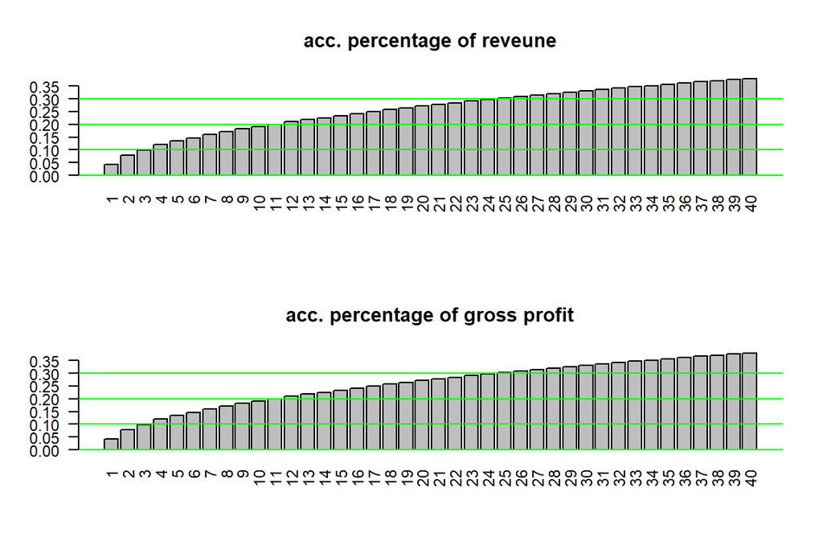

```r
par(mfrow=c(2,1), cex=0.7)
cats$totalRev %>% sort(dec=T) %>% {cumsum(.)[1:40]/sum(.)} %>%
  barplot(names=1:40,las=2,main="acc. percentage of reveune")
abline(h=seq(0,1,0.1),col='green')

cats$totalRev %>% sort(dec=T) %>% {cumsum(.)[1:40]/sum(.)} %>%
  barplot(names=1:40,las=2,main="acc. percentage of gross profit")
abline(h=seq(0,1,0.1),col='green')
```

**品類的營收和毛利貢獻相當分散**

##### 品類和年齡、地區的關聯性

```r
top20 = tapply(Z0$qty,Z0$cat,sum) %>% sort %>% tail(20) %>% names
```

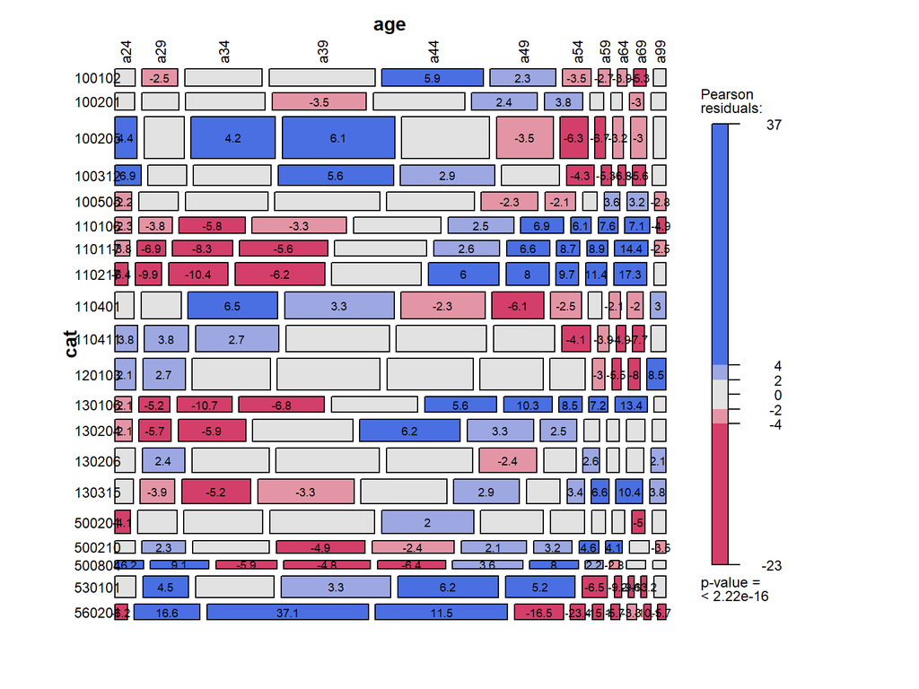

```r
MOSA(~cat+age, Z0[Z0$cat %in% top20,])
```

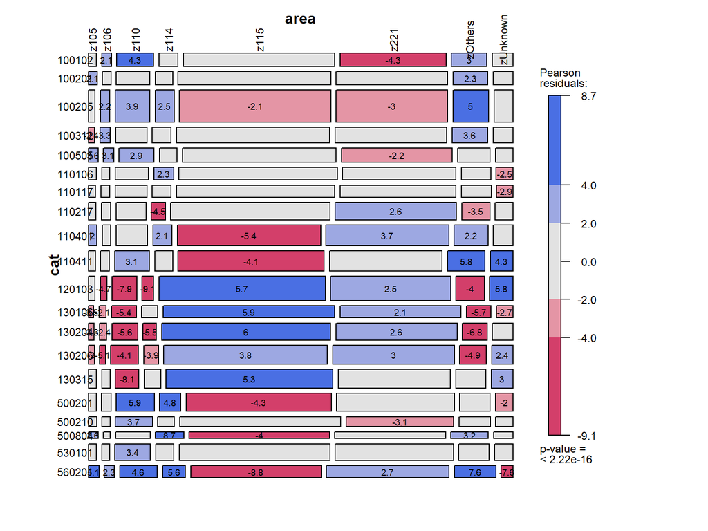

```r
MOSA(~cat+area, Z0[Z0$cat %in% top20,])
```

**不同年齡、地區的顧客喜歡買的品類看來也不太一樣**

### 周末與周間

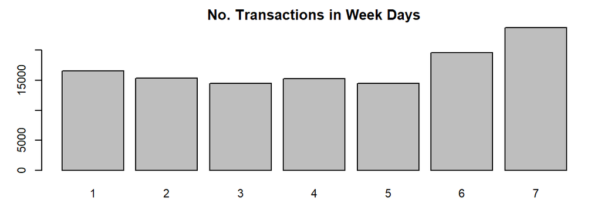

```r
X0$wday = format(X0$date, "%u")
par(cex=0.7, mar=c(2,3,2,1))
table(X0$wday) %>% barplot(main="No. Transactions in Week Days")
```

##### 年齡與購物日的關聯性

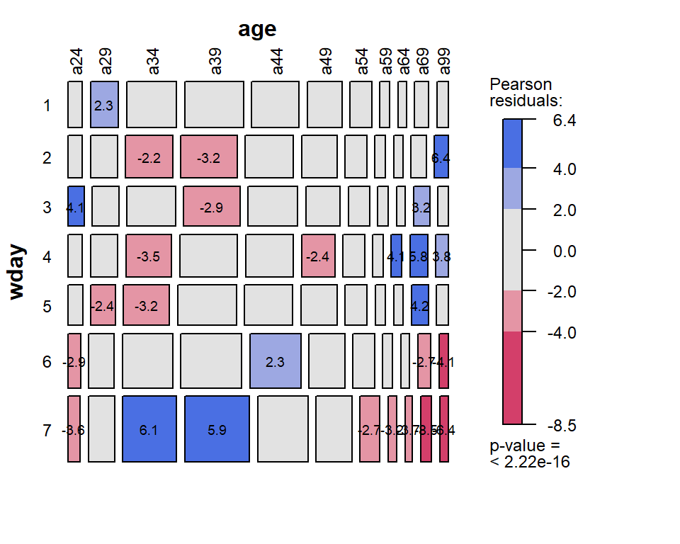

```r
MOSA(~wday+age, X0)
```

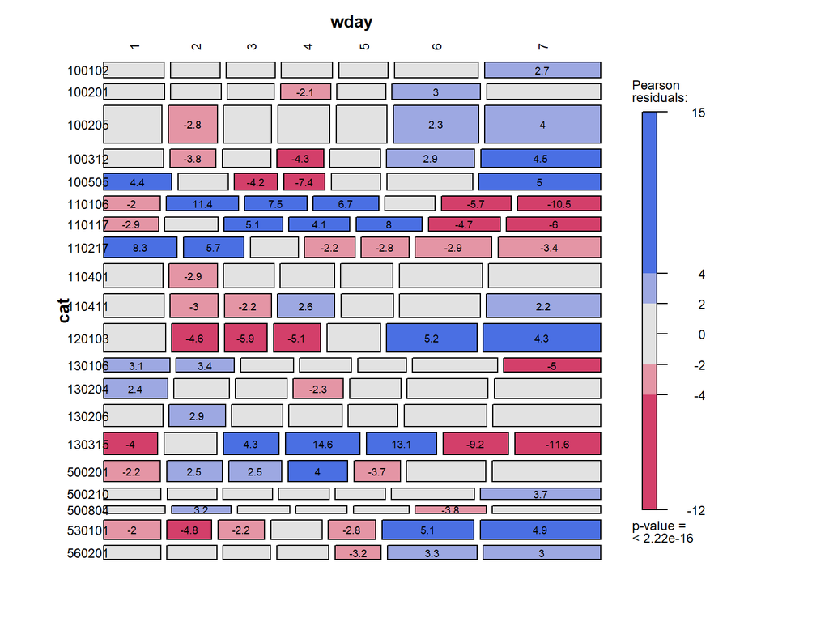

```r
df = Z0 %>% filter(cat %in% top20) %>% mutate(wday = format(date, '%u'))
MOSA(~cat+wday, df)
```